# Investigating the Relationship between Different Mental Health Risk Factors For Data2x02 Students

470354388

17 September, 2022 22:12

# 1 Introduction

Poor mental health is an issue that effects Australians of all ages. Recent studies, such as AIHW (2021) have shown that university students suffer from mental health challenges at a greater proportion than the population. This report aims to use the data gathered by a survey of Data2x02 students to investigate trends in the mental health reported, as well as identifying variables that could significantly indicate higher risk individuals for poor mental health.

The validity of the results of this report may be affected by biases in the data set. This data set is not random, and may be affected by survivorship bias. Specifically, this report focuses on students’ reported anxiety levels on one given day. Students with chronic mental health issues may not attend class (David Lawrence (2019)), or may not have been able to fill out this survey, leading to a non-representative sample.

For the purposes of this report, the study would have had better results to ask students throughout the course of a semester, instead of on a single day.

Question-wording bias could have also had an effect on the results. The original question “How often would you say you feel anxious on a daily basis?” does not directly ask about the respondents mental health situation. Although day to day anxiety does not necessarily mean a person is suffering from mental health problems, it is closely related enough for the purposes of this report. However, if the survey was to be conducted again, questions such as “Do you suffer from a stress related mental health condition” or “Have you felt in the past year that university has effected your mental health? If so in a good way or a bad way?” would be more valid for research conducted around mental health.

Another variable that could have been affected in this report is the study_hrs, where students might be confused if that refers to in class time or only private study.

# 2 Data Cleaning

This report was produced using R (R Core Team 2020) within the Rmarkdown environment (Xie, Allaire, and Grolemund 2018) for reproducibility. Data cleaning was almost entirely using tidyverse (Wickham et al. 2019). Graphs were produced with ggplot2 (Wickham et al. 2019).

Data was wrangled differently for each question. NA’s were removed on a case by case basis. Each section will provide an explanation of the wrangling involved and the reasoning behind the decisions made.

This report borrowed formatting and code snippets from Tar (2022)

# 3 Results

## 3.1 Question 1 - How is Reported Anxiety Levels distributed Among Different Year Groups

To begin, it was worth simply investigating whether the proportion of students who reported feeling anxious was of roughly equal proportion, and if the proportions changed when the sample was split based on what stage of uni they were currently attending. Orygen (2017) reports that the proportion of students who report mental health issues increases from first to second year and beyond, this will be formally tested to discover if there is a significant difference.

### 3.1.1 Data Cleaning

Firstly the data was filtered out by study load. This question only wants to focus on full time uni students, as higher study load has been reported to have a large impact on the mental health of students by Stenger (2018). Then the anxiousness of the respondent was divided into one of 4 categories based on the numeric value obtained: Bad, Medium Bad, Medium Good and Good.

```r
#Question 1 - proportions of good vs bad mental health - are the proportions the same?


data_1 <- raw_data %>%
  filter(study_load == 'Full time') %>% #filter for full time
  select(c(feel_anxious)) %>% #only select the responses to feel anxious
  drop_na() %>% #remove non-responses
  mutate(category = cut(feel_anxious, breaks = c(-Inf, 2.5, 5, 7.5, Inf),
                        labels = c("Bad", "Medium_Bad", "Medium_Good", "Good"))) %>% # split into 4 categories based on numeric results. 4 was chosen because it divides somewhat evenly into 10
  group_by(category) %>%
  summarise(Counts = n()) # convert into a table of counts

knitr::kable(data_1, caption = "Table 1: Counts of the 4 levels of reported anxiety")
```

Table 1: Counts of the 4 levels of reported anxiety

| category | Counts |
| --- | --- |
| Bad | 30 |
| Medium_Bad | 66 |
| Medium_Good | 49 |
| Good | 52 |

```r
 chi_res <- chisq.test(data_1$Counts, p = c(0.25,0.25,0.25,0.25))
```

We are assuming that the levels of anxiety will be uniformly distributed as there is no simple or concrete way to create a model for different theoretical mental health proportions of university students within this report.

- Hypothesis: $H_0$: the proportions are equal vs $H_1$: at least one proportion is not equal.
- Assumptions: That the observations are independent, and $e_i$ = $np_i \ge 5$, which we have confirmed to be TRUE.
- Test statistic: $T = \sum_i^k \frac{(Y_i - e_i)^2}{e_i}$.
- P-value: P($\chi^2_2 \ge$ 13 ) = 0.00389
- Decision: Reject $H_0$. The anxiety levels are not uniformly distributed.

```r
data_2 <- raw_data %>%
  filter(study_load == 'Full time') %>% #only want full timers
  select(c(feel_anxious, uni_year)) %>% # grab the cols we want to analyze
  drop_na() %>% # removing rows with Na values
  group_by(uni_year) %>%
  mutate(category = cut(feel_anxious, breaks = c(-Inf, 2.5, 5, 7.5, Inf),
                        labels = c("Bad", "Medium_Bad", "Medium_Good", "Good"))) %>% #separate the numerical data into 4 categorical sets
  group_by(uni_year, category) %>%
  summarise(Counts = n()) %>% #counting the number of each category
  pivot_wider(names_from = uni_year, values_from = Counts) %>%
  rename_all(~str_replace_all(., "\\s+", "_")) %>% #changing some column names
  mutate_at(c('Fifth_or_higher_year','First_year'), replace_na, 0) %>% #making NAs = 0 as they will be useful for calculations
  ungroup() %>%
  group_by(category) %>%
  mutate(Third_or_above = sum(Fifth_or_higher_year, Fourth_year, Third_year)) %>% # aggregating small groups into single larger group
  mutate(Second_or_below = sum(First_year, Second_year)) %>% #same as above but with first and second years
  select(-c(Fifth_or_higher_year, Fourth_year, Third_year, First_year, Second_year)) #drop cols we no longer need

knitr::kable(data_2, caption = "Table 2: Counts of the 4 levels of reported anxiety based on approximate year of study") #print the table
```

Table 2: Counts of the 4 levels of reported anxiety based on approximate year of study

| category | Third_or_above | Second_or_below |
| --- | --- | --- |
| Bad | 10 | 20 |
| Medium_Bad | 19 | 47 |
| Good | 19 | 33 |
| Medium_Good | 12 | 37 |

```r
graph_data <- data_2 %>% # make a table that has proportions rather than counts so the graph represents the data better
  mutate(Third_or_above_proportion = (Third_or_above)/sum(data_2$Third_or_above)) %>%
  mutate(Second_or_below_proportion = (Second_or_below )/sum(data_2$Second_or_below )) %>%
  select(-c(Second_or_below , Third_or_above )) %>%
  pivot_longer(!category, names_to = "uni_year")
```

We now want to see visually how the proportions of the 2 different groups compared:

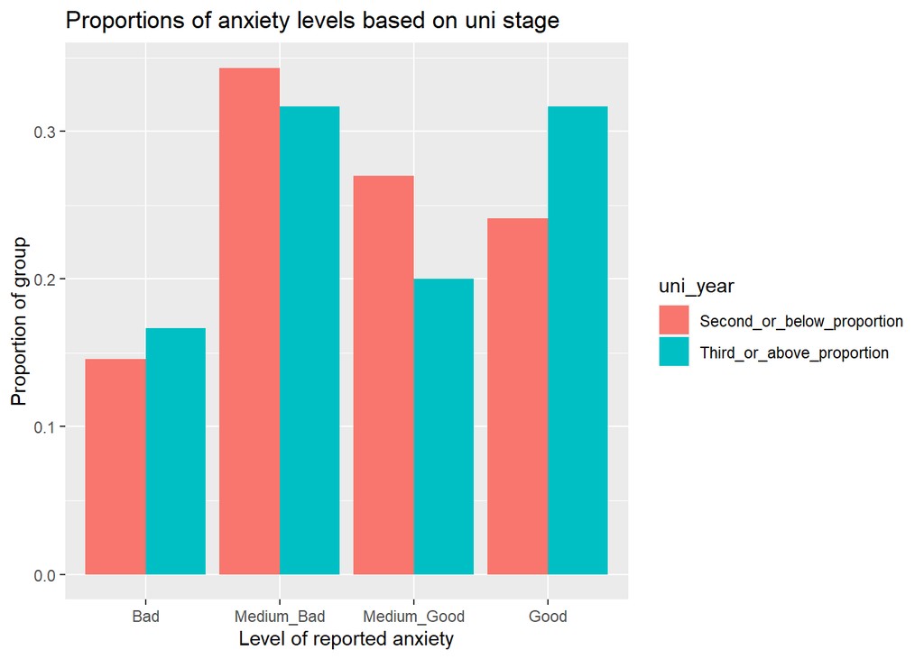

```r
p3 <- ggplot(data = graph_data, aes(x = category, y = value, fill = uni_year)) +
  geom_bar(stat="identity", position=position_dodge()) +
  labs(title = "Proportions of anxiety levels based on uni stage", y = "Proportion of group", x = "Level of reported anxiety", colour = "Year of Study")

p3
```

```r
chi_res_2 <- chisq.test(as.matrix(data_2[,-1]))

set.seed(1)
chi_res_2_sim <- chisq.test(as.matrix(data_2[,-1]), simulate.p.value = TRUE) #Monte Carlo simulation
```

Now we want to perform a something chi-square test to see if there is a significant difference between these two groups.

- Hypothesis: $H_0$: The proportions between the two groups are the same vs $H_1$: The proportions between the two groups are different.
- Assumptions: That the observations are independent, and $e_i$ = $np_i \ge 5$, which we have confirmed to be TRUE.
- Test statistic: $T = \sum_i^k \frac{(Y_i - e_i)^2}{e_i}$.
- P-value: P($\chi^2_2 \ge$ 1.9 ) = 0.586
- Decision: Accept $H_0$. The anxiety levels are not different between different stages of study.

If we were to simulate these p-values because the assumptions weren’t met, our simulated p-value would be 0.599

## 3.2 Question 2 - Does having COVID-19 Effect Students’ WAM

Essadek and Rabeyron (2020) showed that the COVID-19 pandemic had a drastic effect on the mental health of students in France. This next section will explore whether being diagnosed with COVID-19 has had an effect on the mental health ratings of students in Data20x2.

### 3.2.1 Data Cleaning

We filtered out WAMs less than 30 as they seem unreasonably low and could be an error or fake data. This time we didn’t filter out part time students as their WAM could have as easily been effected by COVID-19. In this data we dropped NA values as setting to any other value would contaminate the data.

```r
# Question 2 - COVID-19 and mental health - compare - two sample t test, check if the average is significantly different

data_3 <- raw_data %>% #did not filer full timers out this time as it would not really effect WAM
  select(c(covid_positive,wam)) %>%
  filter(wam > 30) %>% #remove outliers
  drop_na() %>%
  group_by(covid_positive)

summary_data_3 <- data_3 %>%
  summarise(n = n(),
            Mean_WAM = mean(wam) %>% signif(2),
            SD_WAM = sd(wam) %>% signif(2)
            ) #create a nice summary table
knitr::kable(summary_data_3)
```

| covid_positive | n | Mean_WAM | SD_WAM |
| --- | --- | --- | --- |
| No | 86 | 72 | 11 |
| Yes | 71 | 77 | 9 |

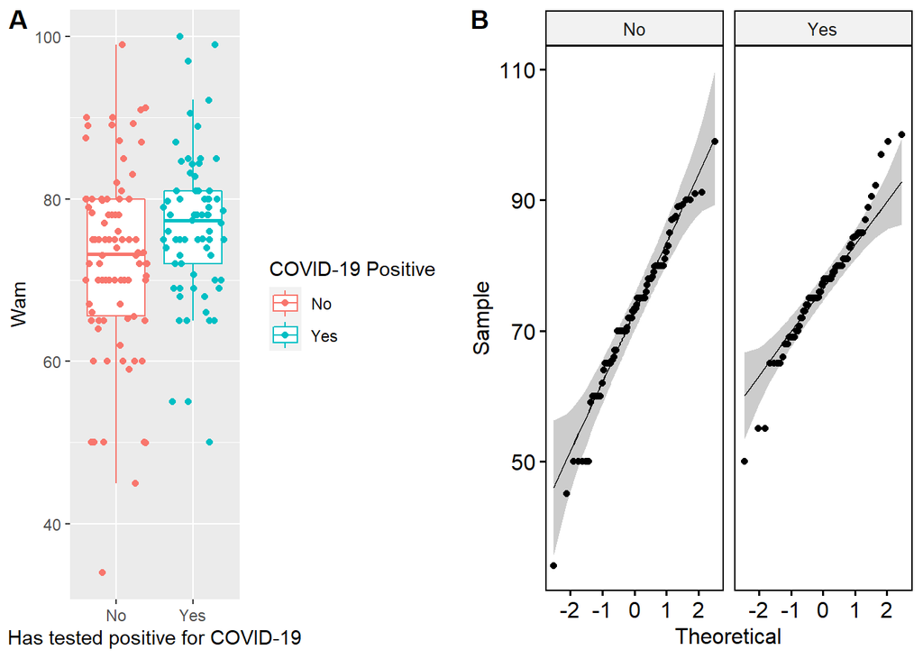

```r
p1 <-  ggplot(data_3 ,aes(x = covid_positive, y = wam, colour = covid_positive)) +
  geom_boxplot(outlier.shape = NA) + #remove outliers so not confused with jitter
  geom_jitter()   +
  labs(y = "Wam", x = "Has tested positive for COVID-19", colour = "COVID-19 Positive")

p2 <-   ggqqplot(data_3, x = "wam", facet.by = "covid_positive")

plot_grid(p1, p2, labels = "AUTO")
```

Based on the QQ plot, our sample is almost normally distributed. However, we need to check our population variances.

```r
f_test <- var.test(data_3$wam[data_3$covid_positive == "Yes"], data_3$wam[data_3$covid_positive == "No"]) #testing for equal variances
```

After performing an F-test to check variance differences, the p-value is 0.042 is less that the significance level 0.05, we cannot accept equal variance. Because of this, we will conduct a Welch test.

```r
t_test <- t.test(data_3$wam[data_3$covid_positive == "Yes"], data_3$wam[data_3$covid_positive == "No"]) #2 sample t test
```

- Hypothesis: Let $\mu_A$ and $\mu_C$ be the population means for respondents who have tested COVID positive and COVID negative respectively. $H_0$: $\mu_A$ = $\mu_C$ $H_1$: $\mu_A \ne \mu_C$
- Assumptions: The two populations are normally distributed (the points are all reasonably close to the line in the QQ plot in the right panel of the figure but do not have the same variance.
- Test statistic: $t_0 = \frac{m_A - m_C}{s_p \sqrt{\frac{1}{n_A} + \frac{1}{n_C}}}$
- Observed test statistic: $t_0$ = 2.62
- p-value: P($t_{154.7164348} \le 2.62) = 0.0098$
- Decision: The p-value is less than 0.05, we reject $H_0$ and conclude there is a significant difference in the mean WAM of people who have tested positive and negative for COVID.

## 3.3 Question 3 - Do Different Employment Types Have a Significant Effect of Study Hours

### 3.3.1 Data Cleaning

For this data, we combined any of the miscellaneous work types so that we were dealing with the four main types: Unemployed, Casual, Part time and Full time. We removed anyone records with study_hrs = 0 because they could be false records.

Below we have graphed the average work hours against study hours between different employment types. They outliers were removed, as the purpose of this graph is to get a general idea of what the trends may be. It seems that there is a very loose downward trend between employment hours and study hours, however there does not seem to be a noticeable difference between casual and part time employees.

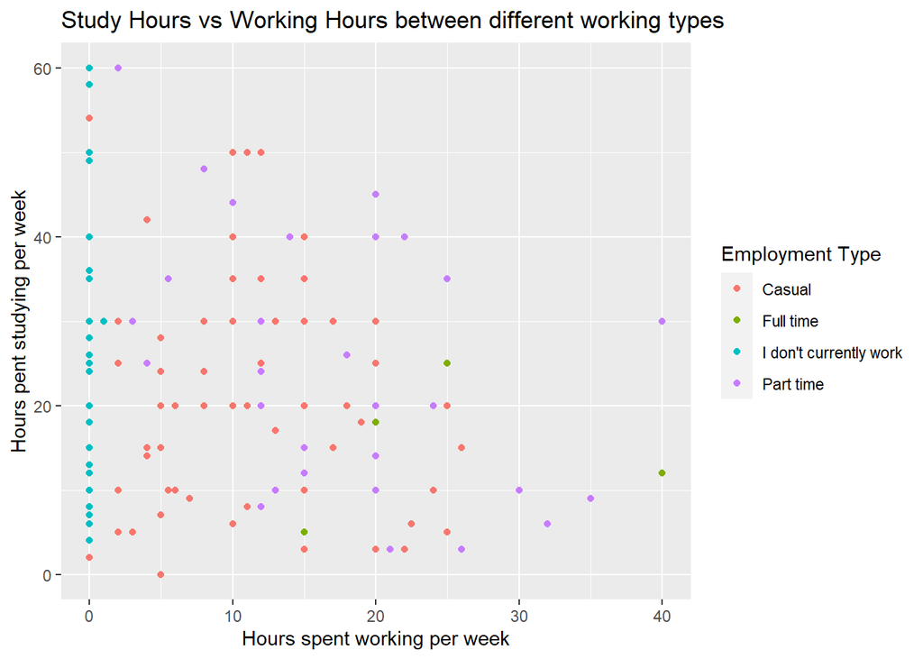

```r
# Question 3 -

data_4 <- raw_data %>%
  filter(study_load == 'Full time') %>%
  select(c(study_hrs, work)) %>%
  drop_na() %>%
  mutate(work = recode(work, "Part time, self employed and contractor" = "Part time", "Casual and Contractor on different jobs" = "Casual", "Self employed" = "Casual", "Doing internship during the vacation" = "I don't currently work", "Contractor" = "Part time"))  %>% #aggregated some of the misc work types into more popular types so that we only have 4 groups to work with
  filter(work %in% c("Casual", "Part time")) %>% #collect only the cols we want to analyze
  filter(study_hrs != 0)

graph_data_5 <- raw_data %>%
  filter(study_load == 'Full time') %>%
  select(c(study_hrs, work, employment_hrs)) %>%
  drop_na() %>%
  mutate(work = recode(work, "Part time, self employed and contractor" = "Part time", "Casual and Contractor on different jobs" = "Casual", "Self employed" = "Casual", "Doing internship during the vacation" = "I don't currently work", "Contractor" = "Part time")) %>%
  filter(study_hrs <= 61) %>% #filtering outliers to make the graph easier to show trends
  filter(employment_hrs <= 40)


p4 <-   ggqqplot(data_4, x = "study_hrs", facet.by = "work")
p5 <- ggplot(graph_data_5) +
  aes(x = employment_hrs,
      y = study_hrs,
      colour = work) +
  geom_point() +
   labs(title = "Study Hours vs Working Hours between different working types", x = "Hours spent working per week", y = "Hours pent studying per week", colour = "Employment Type")
p5
```

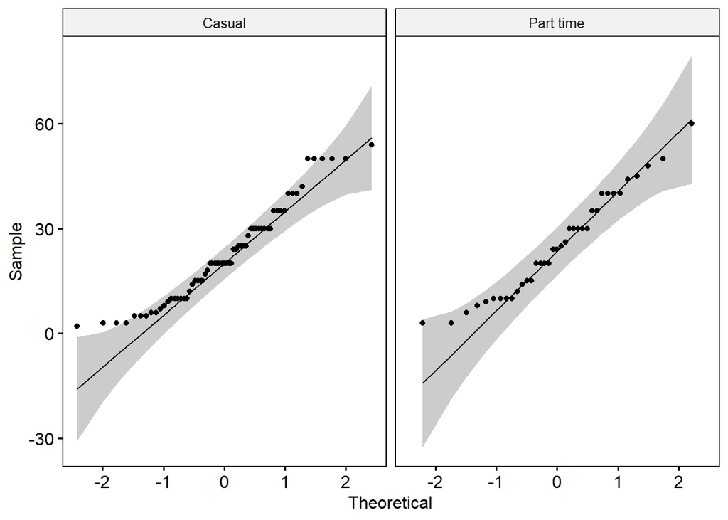

```r
p4
```

```r
part_time_test <- t.test(data_4[data_4$work == "Casual", "study_hrs"], mu = 30, alternative = "less") #one sample t test
casual_test <- t.test(data_4[data_4$work == "Part time", "study_hrs"], mu = 30, alternative = "less")
```

# 4 Conclusion

There are many factors that can contribute to poor mental health in university students. We have shown that the anxiety levels of Data2x02 students is not uniformly distributed, however there seems to be no significant skew in anxiety as these students spend more years studying.

There also seems to be some significant effect that being diagnosed with COVID has on these students WAM. More research would need to be spent finding out which group does better in their studies and why.

# References

AIHW, Australian Government. 2021. *Australia’s Youth: Mental Illness*. https://headspace.org.au/our-organisation/media-releases/majority-of-aussie-students-stressed-depressed/.

David Lawrence, Stephen Houghton, Vaille Dawson. 2019. *Impact of Mental Disorders on Attendance at School*. https://research-repository.uwa.edu.au/en/publications/impact-of-mental-disorders-on-attendance-at-school.

Essadek, Aziz, and Thomas Rabeyron. 2020. “Mental Health of French Students During the Covid-19 Pandemic.” *Journal of Affective Disorders* 277: 392–93. https://doi.org/https://doi.org/10.1016/j.jad.2020.08.042.

Nelson, Vicki. 2022. *Student Study Time Matters*. https://www.collegiateparent.com/academics/student-study-time-matters/.

Orygen, The National Centre of Excellence in Youth Mental Health. 2017. *Under the Radar: The Mental Health of Australian University Students*. https://www.orygen.org.au/Orygen-Institute/Policy-Reports/Under-the-radar/Orygen-Under_the_radar_report.

R Core Team. 2020. *R: A Language and Environment for Statistical Computing*. Vienna, Austria: R Foundation for Statistical Computing. https://www.R-project.org/.

Stenger, Marianne. 2018. *Don’t Overload Students: Assigning Too Much Work Discourages Learning*. https://www.opencolleges.edu.au/informed/features/dont-overload-students-assigning-too-much-work-discourages-learning/.

Susan Bahrami, Hasan Ashrafi Rizi, Saeed Rajaeepour. 2011. *The Relationship Between Students’ Study Habits, Happiness and Depression*. https://www.ncbi.nlm.nih.gov/pmc/articles/PMC3249802/.

Tar, Garth. 2022. *Palmer Archipelago Penguins*. https://pages.github.sydney.edu.au/DATA2002/2022/report/report_hd.html#ref-R-base.

Wickham, Hadley, Mara Averick, Jennifer Bryan, Winston Chang, Lucy D’Agostino McGowan, Romain François, Garrett Grolemund, et al. 2019. “Welcome to the tidyverse.” *Journal of Open Source Software* 4 (43): 1686. https://doi.org/10.21105/joss.01686.

Xie, Yihui, J. J. Allaire, and Garrett Grolemund. 2018. *R Markdown: The Definitive Guide*. Boca Raton, Florida: Chapman; Hall/CRC. https://bookdown.org/yihui/rmarkdown.